# Bootstrapping

Spring 2019

## Bootstrapping By Hand

The process of bootstrapping makes use of resampling with replacement. Thankfully, R has a **sample** function that returns from a vector or list, a sample of a given size taken with or without replacement. We make use of **sample** to create a function to bootstrap the **median** of a vector of values.

### Create Functions

```r
  b.median = function(data, num){
    ### Generate num resample from data --- one for each i = 1 to num
    resamples <- lapply(1:num, function(i){sample(data, replace=TRUE)})

    ## Get the median of each of the resamples
    r.median <- sapply(resamples, median)

    ### Compute the standard error of the median from the num medians
    std.err <- sqrt(var(r.median))

    ### Return a list containing the std error , the resamples, and their medians
    list(std.err = std.err, reamples = resamples, medians = r.median)
  }
```

Having created a function to bootstrap the **median**, it is easy to create a function to bootstrap the **mean.**

```r
  ### Create a copy of the b.median function called b.mean
  b.mean <- b.median
```

We now edit the function by entering into the console one of

```r
  ### Edit and replace
  fix(b.mean)

  ### Edit and assign
  b.mean <- edit(b.mean)
```

Note that we could have used **edit** to take care of both operations at the same time.

```r
  b.mean <- edit(b.median)
```

This approach is fast but prone to overwriting the “good” version.

The **b.mean** function should be modified by replacing occurences of “median” with “mean”. This results in

```r
  b.mean <- function(data, num){
  ### Generate num resample from data --- one for each i = 1 to num
  resamples <- lapply(1:num, function(i){sample(data, replace=TRUE)})

  ## Get the median of each of the resamples
  r.mean <- sapply(resamples, mean)

  ### Compute the standard error of the median from the num medians
  std.err <- sqrt(var(r.mean))

  ### Return a list containing the std error , the resamples, and their medians
  list(std.err = std.err, reamples = resamples, means = r.mean)
  }
```

### Run the Functions

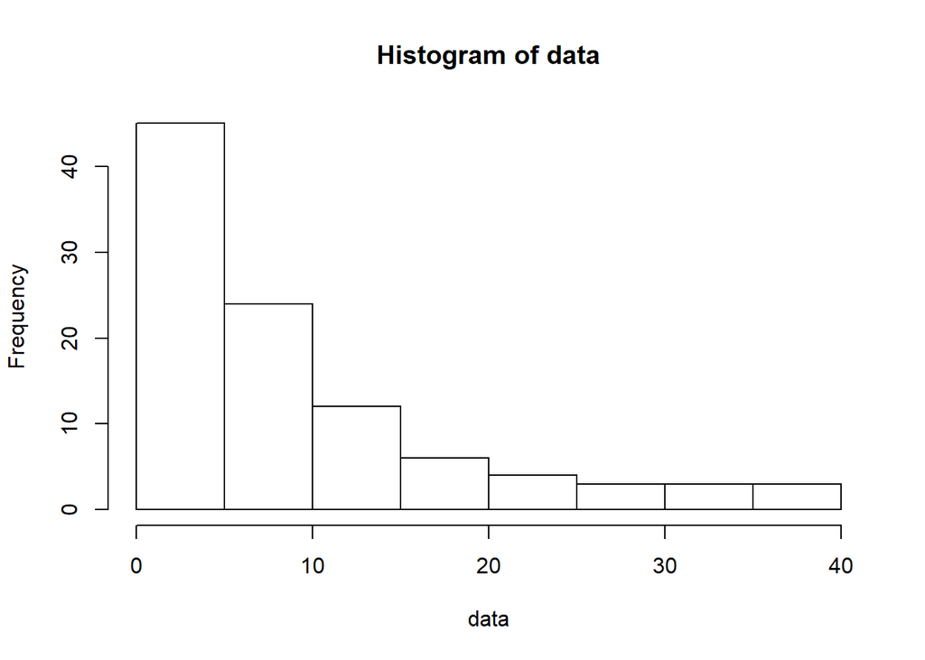

```r
  ### Create 100 observations from an exponential with mean 10
  data <- round(rexp(100, 1/10))
  hist(data)
```

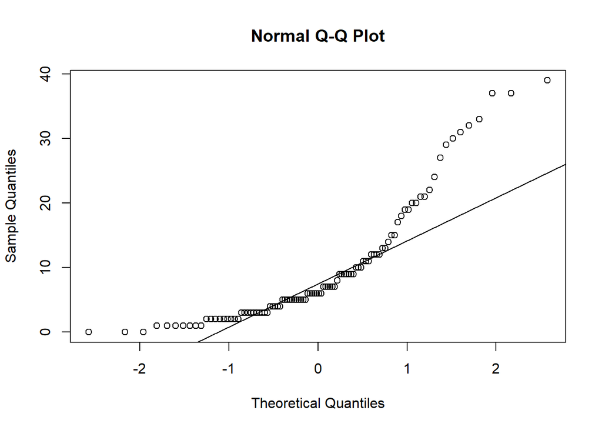

```r
  qqnorm(data)
  qqline(data)
```

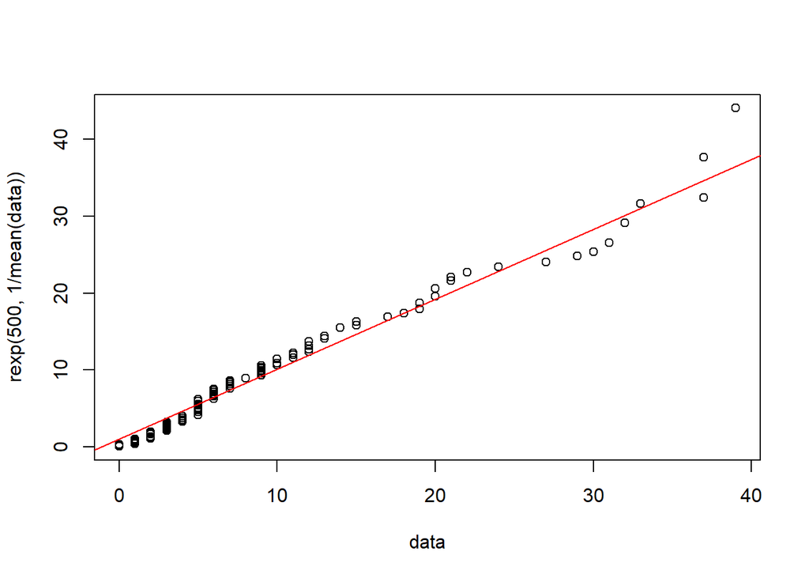

```r
  qqplot(data, rexp(500, 1/mean(data)))
  qqline(data, distribution = function(p) qexp(p, 1/mean(data)),
       prob = c(0.1, 0.6), col = 2)
```

```r
  ### Check the first 10 observations
  cat("First 10 obs of original sample: ", data[1:10], "\n")
```

```
## First 10 obs of original sample:  12 10 2 6 4 9 3 19 1 2
```

```r
  ### Compute 10000 bootstrap samples for the mean
  data.b.mean <- b.mean(data, 10000)

  ### Check the standard error
  cat("se(xbar) = ", data.b.mean$std.err, "\n")
```

```
## se(xbar) =  0.9225718
```

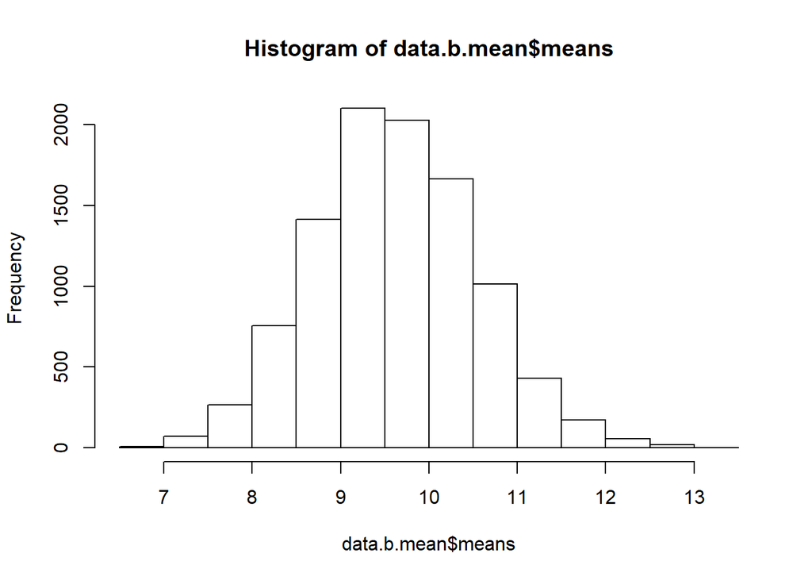

```r
  ### Look at the bootstrap distribution
  hist(data.b.mean$means)
```

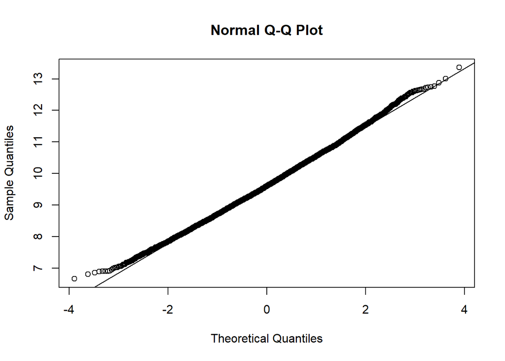

```r
  qqnorm(data.b.mean$means)
  qqline(data.b.mean$means)
```

```r
  ### Compute 10000 bootstrap samples for the median
  data.b.median <- b.median(data, 10000)

  ### Check the standard error
  cat("se(m) = ", data.b.median$std.err, "\n")
```

```
## se(m) =  0.8487821
```

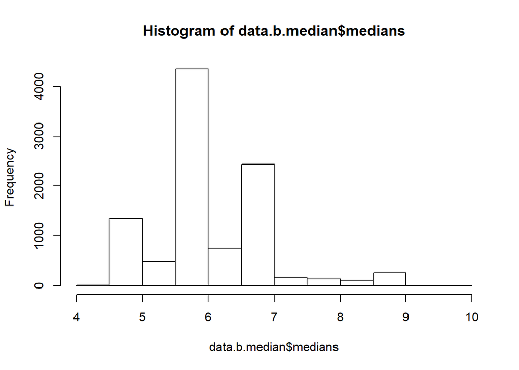

```r
  ### Look at the bootstrap distribution
  hist(data.b.median$medians)
```

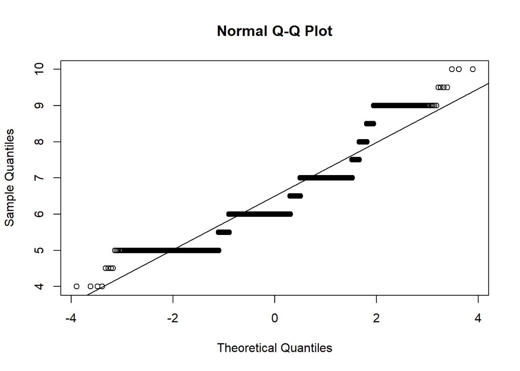

```r
  qqnorm(data.b.median$medians)
  qqline(data.b.median$medians)
```

If we use the same “data” as before and repeat the bootstrapping, we get a different results because of different samples.

## The **boot** Package

R has a **boot** package that makes it easy to implement bootstrapping on “complex” statistics.

### Mean

We can use **boot** to replicate the bootstrapping that was carried out above.

```r
  p_load(boot)
  ### The boot.mean takes the original data (d) and computes the mean of the
  ### selected, indexed (i) values (d[i])
  boot.mean <- function(d, i){mean(d[i])}
  data.boot.mean <- boot(data, boot.mean, R=10000)
  summary(data.boot.mean)
```

```
##           Length Class  Mode
## t0            1  -none- numeric
## t         10000  -none- numeric
## R             1  -none- numeric
## data        100  -none- numeric
## seed        626  -none- numeric
## statistic     1  -none- function
## sim           1  -none- character
## call          4  -none- call
## stype         1  -none- character
## strata      100  -none- numeric
## weights     100  -none- numeric
```

```r
  data.boot.mean
```

```
##
## ORDINARY NONPARAMETRIC BOOTSTRAP
##
##
## Call:
## boot(data = data, statistic = boot.mean, R = 10000)
##
##
## Bootstrap Statistics :
##     original    bias    std. error
## t1*     9.62 -0.005246   0.9278368
```

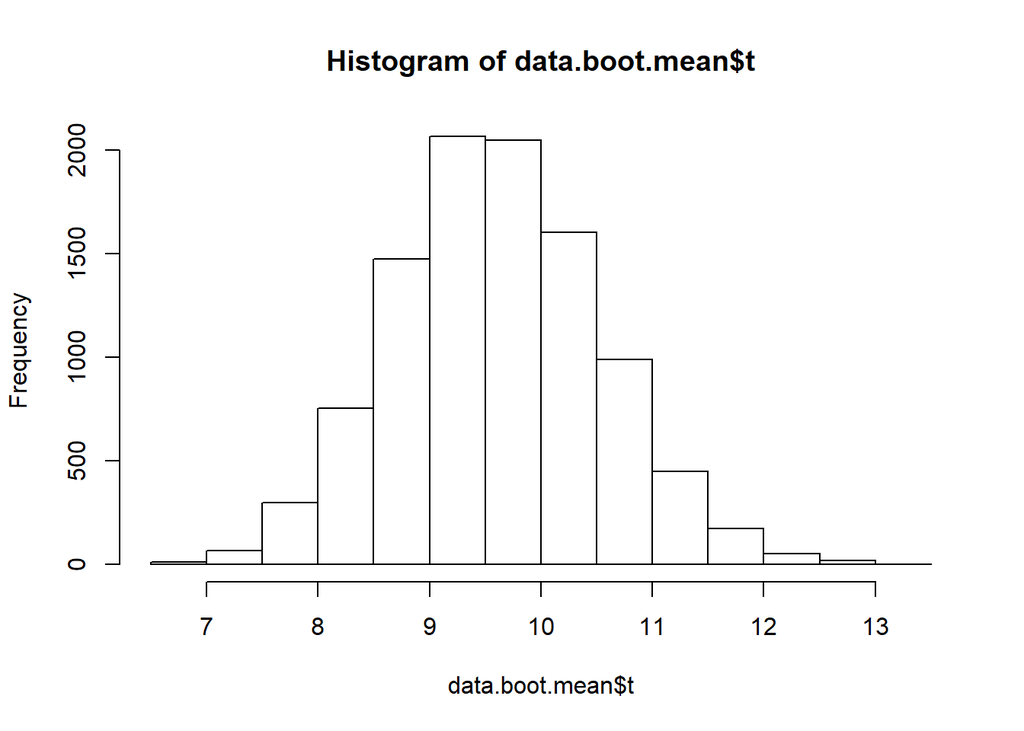

```r
  hist(data.boot.mean$t)
```

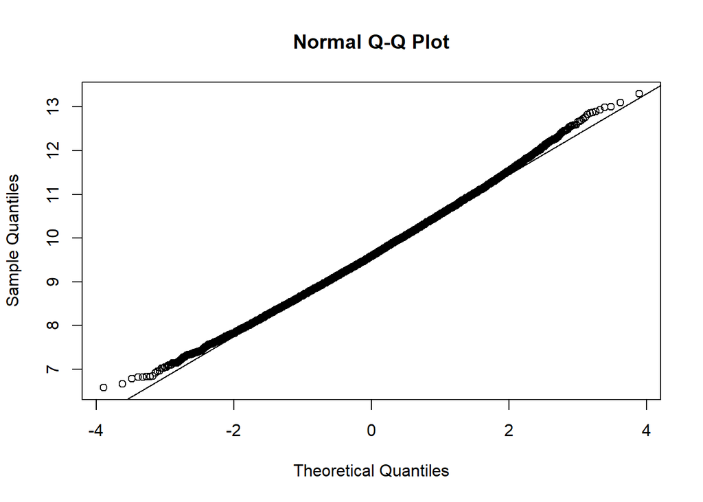

```r
  qqnorm(data.boot.mean$t)
  qqline(data.boot.mean$t)
```

```r
  boot.ci(data.boot.mean)
```

```
## BOOTSTRAP CONFIDENCE INTERVAL CALCULATIONS
## Based on 10000 bootstrap replicates
##
## CALL :
## boot.ci(boot.out = data.boot.mean)
##
## Intervals :
## Level      Normal              Basic
## 95%   ( 7.807, 11.444 )   ( 7.740, 11.380 )
##
## Level     Percentile            BCa
## 95%   ( 7.86, 11.50 )   ( 7.98, 11.68 )
## Calculations and Intervals on Original Scale
```

### Correlation

Computing a confidence interval for the sample correlation can be challenging. Bootstrapping makes this relatively easy.

```r
  htwt <- read.csv("HtWt.csv")
  head(htwt)
```

```
##   Height Weight Group
## 1     64    159     1
## 2     63    155     2
## 3     67    157     2
## 4     60    125     1
## 5     52    103     2
## 6     58    122     2
```

```r
  ### Create a function to compute the correlation of reseampled data
  f <- function(d, i){corr(d[i,])}
  boot.htwt.corr <- boot(htwt[,1:2], f, R=10000)

  boot.htwt.corr
```

```
##
## ORDINARY NONPARAMETRIC BOOTSTRAP
##
##
## Call:
## boot(data = htwt[, 1:2], statistic = f, R = 10000)
##
##
## Bootstrap Statistics :
##      original        bias    std. error
## t1* 0.9868154 -0.0002478202 0.005661326
```

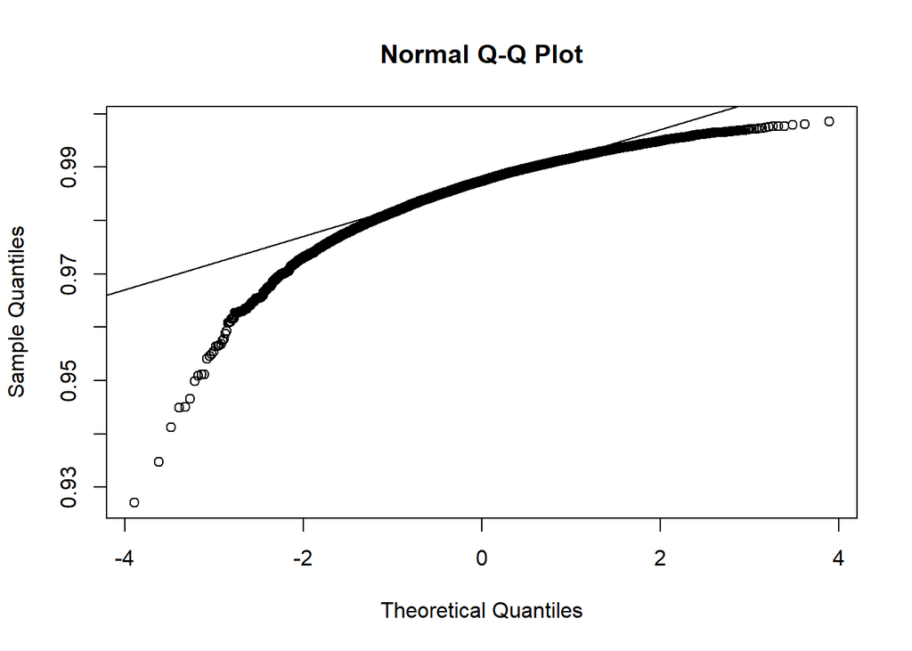

```r
  qqnorm(boot.htwt.corr$t)
  qqline(boot.htwt.corr$t)
```

```r
  boot.ci(boot.htwt.corr)
```

```
## BOOTSTRAP CONFIDENCE INTERVAL CALCULATIONS
## Based on 10000 bootstrap replicates
##
## CALL :
## boot.ci(boot.out = boot.htwt.corr)
##
## Intervals :
## Level      Normal              Basic
## 95%   ( 0.9760,  0.9982 )   ( 0.9788,  1.0003 )
##
## Level     Percentile            BCa
## 95%   ( 0.9734,  0.9948 )   ( 0.9702,  0.9941 )
## Calculations and Intervals on Original Scale
```

### Slope and Intercept

We can bootstrap the slope and intercept of a simple regression model.

```r
  htwt <- read.csv("http://facweb1.redlands.edu/fac/jim_bentley/data/math 312/bootstrap/htwt.csv")
  head(htwt)
```

```
##   Height Weight Group
## 1     64    159     1
## 2     63    155     2
## 3     67    157     2
## 4     60    125     1
## 5     52    103     2
## 6     58    122     2
```

```r
  ### Create a function to compute the correlation of reseampled data
  f <- function(d, i){coef(lm(d$Weight[i] ~ d$Height[i]))}
  boot.htwt.coef <- boot(htwt[,1:2], f, R=10000)

  boot.htwt.coef
```

```
##
## ORDINARY NONPARAMETRIC BOOTSTRAP
##
##
## Call:
## boot(data = htwt[, 1:2], statistic = f, R = 10000)
##
##
## Bootstrap Statistics :
##        original       bias    std. error
## t1* -173.459595 -0.588689709  12.6002354
## t2*    5.041217  0.009350654   0.2007861
```

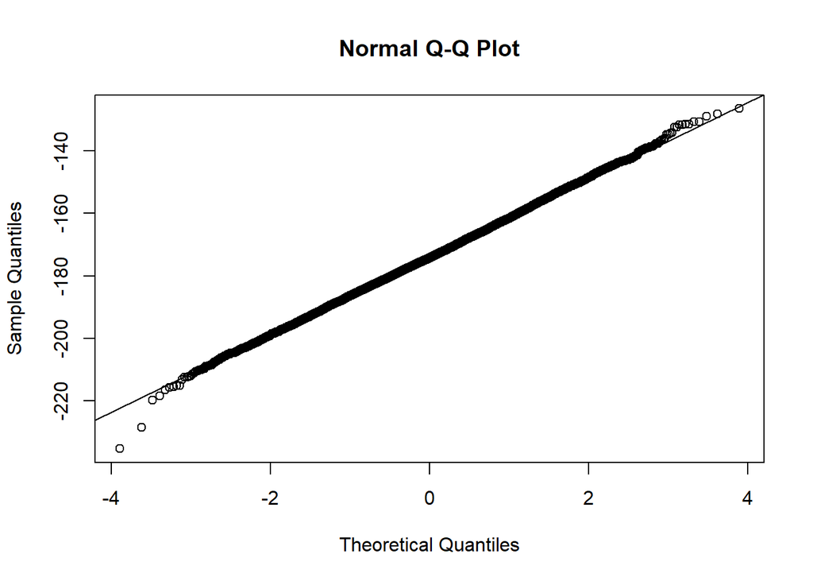

```r
  qqnorm(boot.htwt.coef$t[,1])
  qqline(boot.htwt.coef$t[,1])
```

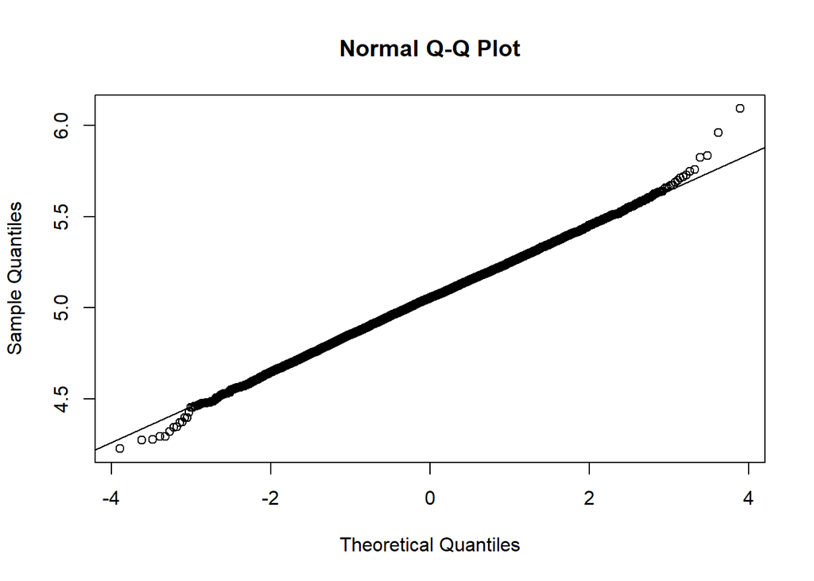

```r
  qqnorm(boot.htwt.coef$t[,2])
  qqline(boot.htwt.coef$t[,2])
```